# TREC & KREC: Twins data

Stéfanne Bortoletto, Carolina Prando and [Henrique Laureano](https://henriquelaureano.github.io/)

Last modification on* 2022-02-04 17:48:31

# TREC & KREC

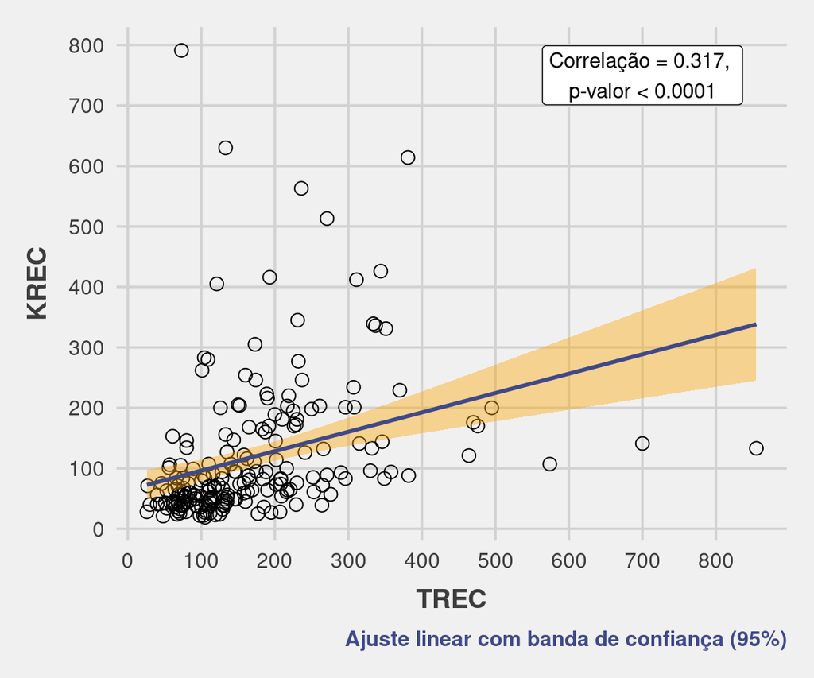

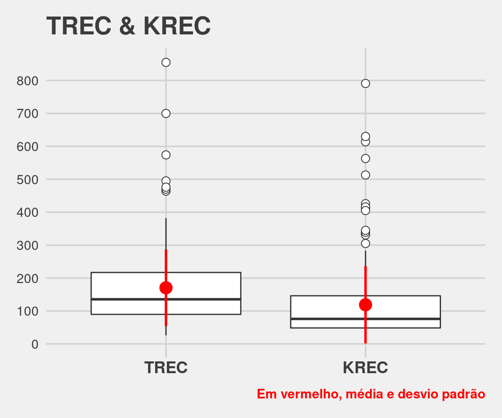

Medidas descritivas

| Variável | Min. | 1st Qu. | Median | Mean | 3rd Qu. | Max. |
| --- | --- | --- | --- | --- | --- | --- |
| TREC | 26 | 89.75 | 135.5 | 170.415 | 217.00 | 855 |
| KREC | 19 | 48.50 | 76.0 | 118.895 | 146.25 | 791 |

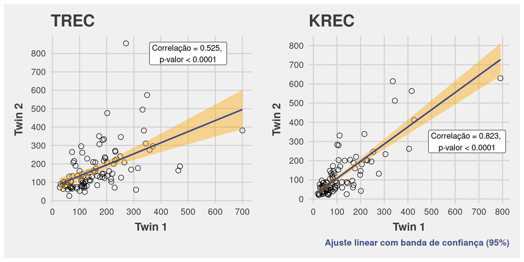

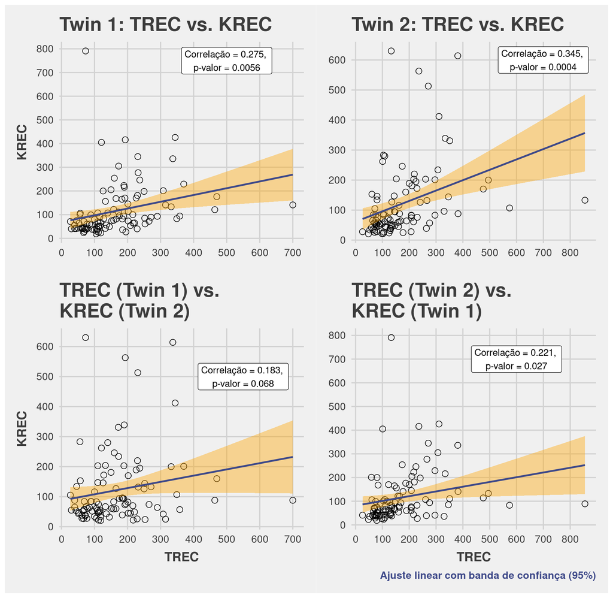

[figure not shown]

Medidas descritivas

| Variável | Min. | 1st Qu. | Median | Mean | 3rd Qu. | Max. |
| --- | --- | --- | --- | --- | --- | --- |
| abs(TREC 1 - TREC 2) | 0 | 24 | 44.5 | 74.15 | 95 | 584 |
| abs(KREC 1 - KREC 2) | 0 | 14 | 30.5 | 47.63 | 59 | 278 |

Testes-t de Welch

| Variável | estimate | estimate1 | estimate2 | p.value | conf.low | conf.high |
| --- | --- | --- | --- | --- | --- | --- |
| dif(TREC 1, TREC 2) | -7.91 | 166.46 | 174.37 | 0.6322 | -40.4535 | 24.6335 |
| dif(KREC 1, KREC 2) | -5.59 | 116.10 | 121.69 | 0.7376 | -38.4539 | 27.2739 |
| dif(abs(TREC 1 - TREC 2), abs(KREC 1 - KREC 2)) | 26.52 | 74.15 | 47.63 | 0.0099 | 6.4477 | 46.5923 |

> Na última tabela fornecida acima performamos três testes de média, na ordem: se a média dos TRECs difere (gêmeo 1 para o 2); se a média dos KRECs difere; e se a diferença média dos TRECs difere da diferença média dos KRECs.

> Temos ali a estimativa da diferença (`estimate`), a média do primeiro grupo (`estimate1`), do segundo grupo (`estimate2`), o valor-*p*, e um intervalo de 95% de confiança para a estimativa.

# Idade gestacional

Medidas descritivas

| Min. | 1st Qu. | Median | Mean | 3rd Qu. | Max. |
| --- | --- | --- | --- | --- | --- |
| 27 | 34.75 | 36 | 35.7 | 38 | 40 |

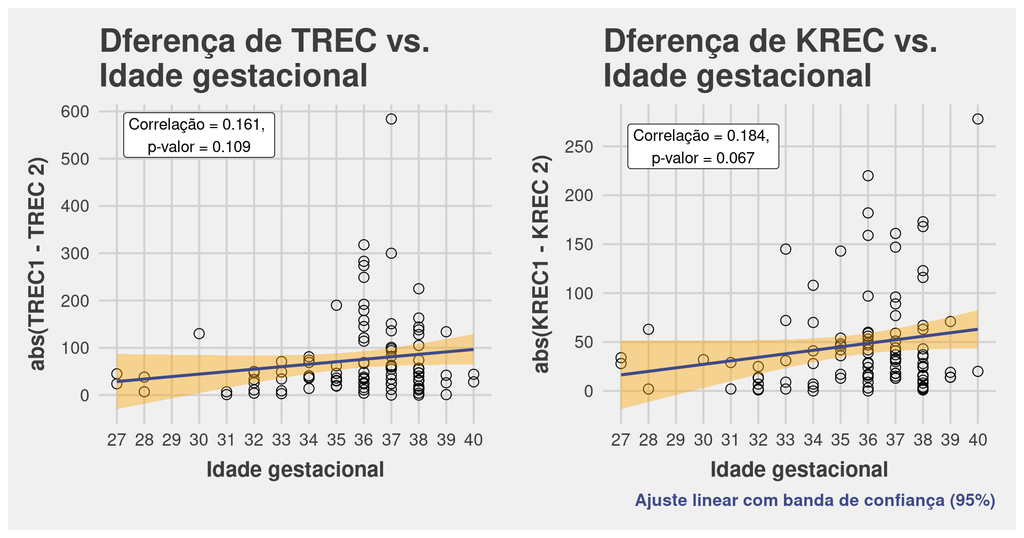

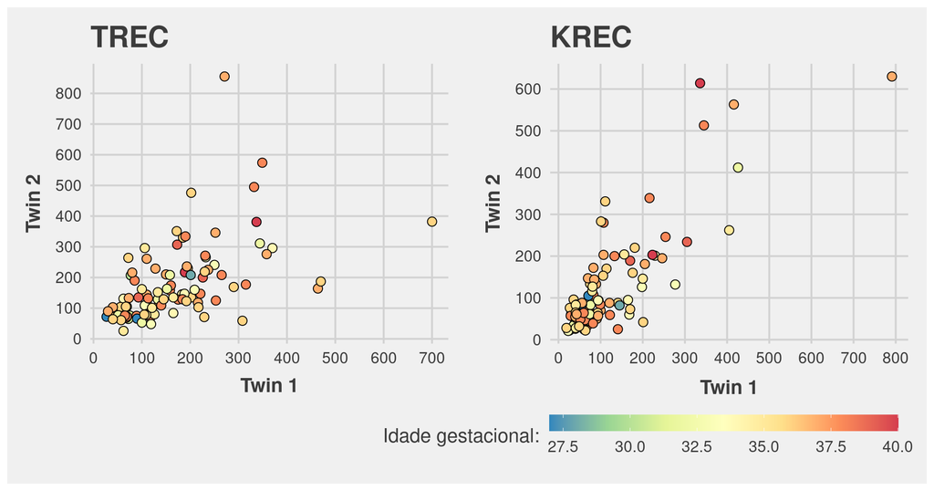

# Tipo de parto

> Desconsideramos o par com tipo de parto não informado:

| ID | id_gest | parto | TREC | KREC |
| --- | --- | --- | --- | --- |
| PG72a | 38 | Não informado | 160 | 254 |
| PG72b | 38 | Não informado | 174 | 246 |

> Na hora de olhar para as diferenças de TREc & KREC, retiramos os dois pares em que o tipo de parto não foi o mesmo:

| ID | id_gest | parto | TREC | KREC |
| --- | --- | --- | --- | --- |
| PG79a | 28 | Normal | 201 | 145 |
| PG79b | 28 | Cesariana | 208 | 82 |
| PG97a | 38 | Normal | 231 | 345 |
| PG97b | 38 | Cesariana | 271 | 513 |

Medidas descritivas (n representa o número de gêmeos, não de pares)

|  | Min. | 1st Qu. | Median | Mean | 3rd Qu. | Max. | n |
| --- | --- | --- | --- | --- | --- | --- | --- |
| **TREC** |  |  |  |  |  |  |  |
| Cesariana | 26 | 84.75 | 134.0 | 171.7011 | 222.00 | 855 | 184 |
| Normal | 79 | 113.25 | 148.5 | 154.0000 | 197.75 | 231 | 14 |
| **KREC** |  |  |  |  |  |  |  |
| Cesariana | 19 | 46.75 | 75.5 | 118.1793 | 141.75 | 791 | 184 |
| Normal | 22 | 52.50 | 82.0 | 109.5714 | 146.50 | 345 | 14 |
| **TRECdif** |  |  |  |  |  |  |  |
| Cesariana | 0 | 25.00 | 47.0 | 78.2198 | 103.00 | 584 | 182 |
| Normal | 14 | 35.00 | 39.5 | 39.3333 | 47.00 | 60 | 12 |
| **KRECdif** |  |  |  |  |  |  |  |
| Cesariana | 0 | 15.00 | 32.0 | 48.4396 | 57.50 | 278 | 182 |
| Normal | 0 | 2.50 | 6.5 | 19.3333 | 20.25 | 77 | 12 |

Testes-t de Welch

| Variável | estimate | estimate1 | estimate2 | p.value | conf.low | conf.high |
| --- | --- | --- | --- | --- | --- | --- |
| TREC | 17.7011 | 171.7011 | 154.0000 | 0.2639 | -14.0927 | 49.4948 |
| KREC | 8.6079 | 118.1793 | 109.5714 | 0.7382 | -44.8830 | 62.0988 |
| TRECdif | 38.8864 | 78.2198 | 39.3333 | 0.0014 | 15.9374 | 61.8355 |
| KRECdif | 29.1062 | 48.4396 | 19.3333 | 0.0626 | -1.9928 | 60.2052 |

> Ignorando o fato de estarmos lidando com gêmeos, e simplesmente comparando as medidas médias de TREC & KREC do grupo `cesariana` com o grupo `normal`, resulta em *p*-valores não significativos (sem diferença significativa entre os tipois de parto).

# Complicação gestacional

> O mesmo par de gêmeos que não tem a informaçao do tipo de parto, também não tem a informação se presenciou complicação gestacional.

| ID | id_gest | parto | complic_gest | TREC | KREC |
| --- | --- | --- | --- | --- | --- |
| PG72a | 38 | Não informado | Não informado | 160 | 254 |
| PG72b | 38 | Não informado | Não informado | 174 | 246 |

Medidas descritivas (n representa o número de gêmeos, não de pares)

|  | Min. | 1st Qu. | Median | Mean | 3rd Qu. | Max. | n |
| --- | --- | --- | --- | --- | --- | --- | --- |
| **TREC** |  |  |  |  |  |  |  |
| Não | 27 | 89.25 | 146.0 | 173.7462 | 220.50 | 855 | 130 |
| Sim | 26 | 90.25 | 126.0 | 164.1471 | 210.75 | 700 | 68 |
| **KREC** |  |  |  |  |  |  |  |
| Não | 19 | 52.50 | 83.0 | 115.2385 | 151.50 | 614 | 130 |
| Sim | 22 | 42.75 | 65.5 | 122.0294 | 132.50 | 791 | 68 |
| **TRECdif** |  |  |  |  |  |  |  |
| Não | 0 | 24.00 | 44.0 | 73.1231 | 82.00 | 584 | 130 |
| Sim | 0 | 32.25 | 47.5 | 77.8824 | 130.50 | 318 | 68 |
| **KRECdif** |  |  |  |  |  |  |  |
| Não | 0 | 15.00 | 29.0 | 43.4000 | 51.00 | 278 | 130 |
| Sim | 0 | 14.00 | 41.0 | 56.8824 | 96.75 | 182 | 68 |

Testes-t de Welch

| Variável | estimate | estimate1 | estimate2 | p.value | conf.low | conf.high |
| --- | --- | --- | --- | --- | --- | --- |
| TREC | 9.5991 | 173.7462 | 164.1471 | 0.5780 | -24.4323 | 43.6305 |
| KREC | -6.7910 | 115.2385 | 122.0294 | 0.7280 | -45.4101 | 31.8282 |
| TRECdif | -4.7593 | 73.1231 | 77.8824 | 0.7879 | -39.8675 | 30.3490 |
| KRECdif | -13.4824 | 43.4000 | 56.8824 | 0.2434 | -36.3669 | 9.4022 |

> Os grupos `não` e `sim` não diferem de maneira significativa em nenhuma das categorias.

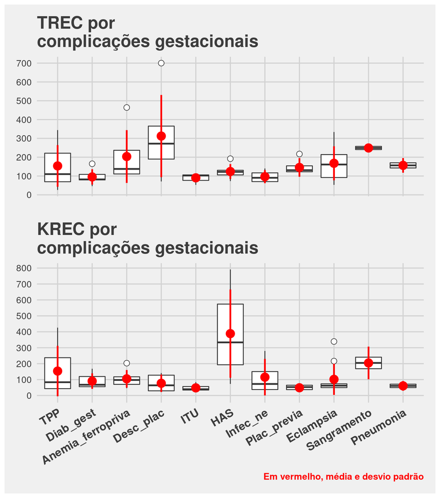

Medidas descritivas

|  | Min. | 1st Qu. | Median | Mean | 3rd Qu. | Max. | n |
| --- | --- | --- | --- | --- | --- | --- | --- |
| **TREC** |  |  |  |  |  |  |  |
| TPP | 26 | 69.50 | 110.0 | 153.60 | 221.25 | 344 | 10 |
| Diab_gest | 46 | 79.25 | 82.0 | 95.17 | 108.75 | 165 | 6 |
| Anemia_ferropriva | 110 | 111.00 | 137.5 | 203.50 | 236.75 | 464 | 6 |
| Desc_plac | 71 | 190.00 | 272.0 | 312.33 | 365.25 | 700 | 6 |
| ITU | 53 | 76.75 | 102.5 | 90.33 | 105.75 | 109 | 6 |
| HAS | 73 | 106.00 | 122.0 | 123.83 | 130.50 | 192 | 6 |
| Infec_ne | 65 | 70.25 | 90.5 | 96.50 | 116.75 | 140 | 4 |
| Plac_previa | 103 | 122.50 | 131.0 | 145.50 | 154.00 | 217 | 4 |
| Eclampsia | 53 | 92.00 | 161.0 | 167.60 | 214.00 | 334 | 10 |
| Sangramento | 232 | 240.50 | 249.0 | 249.00 | 257.50 | 266 | 2 |
| Pneumonia | 129 | 142.75 | 156.5 | 156.50 | 170.25 | 184 | 2 |
| NA | 27 | 90.00 | 151.0 | 174.93 | 220.50 | 855 | 138 |
| **KREC** |  |  |  |  |  |  |  |
| TPP | 27 | 43.25 | 83.5 | 153.50 | 237.50 | 426 | 10 |
| Diab_gest | 52 | 55.50 | 67.5 | 90.50 | 119.25 | 168 | 6 |
| Anemia_ferropriva | 46 | 70.00 | 97.5 | 104.83 | 117.50 | 203 | 6 |
| Desc_plac | 25 | 29.50 | 64.0 | 76.83 | 127.75 | 141 | 6 |
| ITU | 30 | 34.50 | 39.5 | 48.00 | 56.50 | 84 | 6 |
| HAS | 73 | 193.00 | 333.5 | 388.50 | 573.75 | 791 | 6 |
| Infec_ne | 36 | 37.50 | 72.5 | 115.25 | 150.25 | 280 | 4 |
| Plac_previa | 22 | 37.00 | 53.0 | 48.75 | 64.75 | 67 | 4 |
| Eclampsia | 43 | 49.75 | 62.0 | 101.60 | 73.50 | 339 | 10 |
| Sangramento | 132 | 168.25 | 204.5 | 204.50 | 240.75 | 277 | 2 |
| Pneumonia | 39 | 49.75 | 60.5 | 60.50 | 71.25 | 82 | 2 |
| NA | 19 | 50.50 | 82.5 | 114.42 | 151.50 | 614 | 138 |

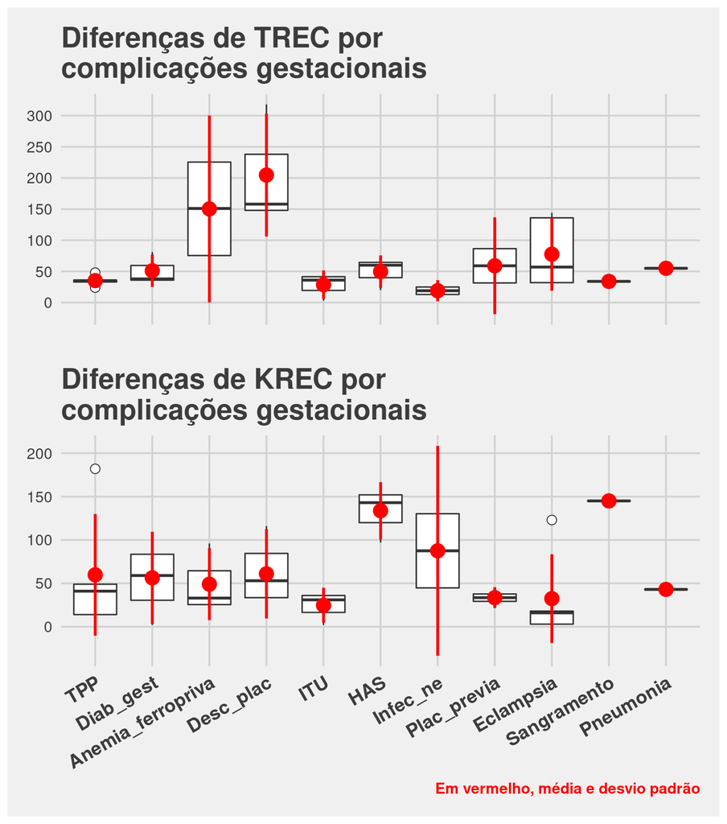

Medidas descritivas

|  | Min. | 1st Qu. | Median | Mean | 3rd Qu. | Max. | n |
| --- | --- | --- | --- | --- | --- | --- | --- |
| **TREC** |  |  |  |  |  |  |  |
| TPP | 24 | 33.00 | 35.0 | 35.20 | 36.00 | 48 | 5 |
| Diab_gest | 34 | 36.00 | 38.0 | 51.00 | 59.50 | 81 | 3 |
| Anemia_ferropriva | 0 | 75.50 | 151.0 | 150.33 | 225.50 | 300 | 3 |
| Desc_plac | 138 | 148.00 | 158.0 | 204.67 | 238.00 | 318 | 3 |
| ITU | 3 | 19.50 | 36.0 | 28.67 | 41.50 | 47 | 3 |
| HAS | 20 | 40.00 | 60.0 | 49.67 | 64.50 | 69 | 3 |
| Infec_ne | 7 | 13.00 | 19.0 | 19.00 | 25.00 | 31 | 2 |
| Plac_previa | 4 | 31.50 | 59.0 | 59.00 | 86.50 | 114 | 2 |
| Eclampsia | 19 | 32.00 | 57.0 | 77.60 | 136.00 | 144 | 5 |
| Sangramento | 34 | 34.00 | 34.0 | 34.00 | 34.00 | 34 | 1 |
| Pneumonia | 55 | 55.00 | 55.0 | 55.00 | 55.00 | 55 | 1 |
| NA | 0 | 24.00 | 45.0 | 74.68 | 94.00 | 584 | 69 |
| **KREC** |  |  |  |  |  |  |  |
| TPP | 13 | 14.00 | 41.0 | 59.80 | 49.00 | 182 | 5 |
| Diab_gest | 2 | 30.50 | 59.0 | 56.33 | 83.50 | 108 | 3 |
| Anemia_ferropriva | 18 | 25.50 | 33.0 | 49.00 | 64.50 | 96 | 3 |
| Desc_plac | 14 | 33.50 | 53.0 | 61.00 | 84.50 | 116 | 3 |
| ITU | 2 | 16.50 | 31.0 | 24.67 | 36.00 | 41 | 3 |
| HAS | 97 | 120.00 | 143.0 | 133.67 | 152.00 | 161 | 3 |
| Infec_ne | 2 | 44.75 | 87.5 | 87.50 | 130.25 | 173 | 2 |
| Plac_previa | 25 | 29.25 | 33.5 | 33.50 | 37.75 | 42 | 2 |
| Eclampsia | 2 | 3.00 | 16.0 | 32.40 | 18.00 | 123 | 5 |
| Sangramento | 145 | 145.00 | 145.0 | 145.00 | 145.00 | 145 | 1 |
| Pneumonia | 43 | 43.00 | 43.0 | 43.00 | 43.00 | 43 | 1 |
| NA | 0 | 14.00 | 28.0 | 42.00 | 51.00 | 278 | 69 |

# Complicação no parto

> Retirando os não informados.

| ID | id_gest | parto | complic_gest | complic_no_parto | TREC | KREC |
| --- | --- | --- | --- | --- | --- | --- |
| PG72a | 38 | Não informado | Não informado | Não informado | 160 | 254 |
| PG72b | 38 | Não informado | Não informado | Não informado | 174 | 246 |

Medidas descritivas (n representa o número de gêmeos, não de pares)

|  | Min. | 1st Qu. | Median | Mean | 3rd Qu. | Max. | n |
| --- | --- | --- | --- | --- | --- | --- | --- |
| **TREC** |  |  |  |  |  |  |  |
| Não | 26 | 83.50 | 135.0 | 169.6591 | 216.75 | 855 | 176 |
| Sim | 56 | 114.25 | 160.5 | 176.7727 | 217.00 | 370 | 22 |
| **KREC** |  |  |  |  |  |  |  |
| Não | 19 | 44.75 | 72.5 | 111.0625 | 128.25 | 791 | 176 |
| Sim | 22 | 79.75 | 184.0 | 169.6364 | 221.25 | 405 | 22 |
| **TRECdif** |  |  |  |  |  |  |  |
| Não | 0 | 25.50 | 43.5 | 76.5000 | 95.75 | 584 | 176 |
| Sim | 9 | 24.00 | 48.0 | 60.8182 | 86.00 | 144 | 22 |
| **KRECdif** |  |  |  |  |  |  |  |
| Não | 0 | 14.00 | 29.0 | 45.0114 | 53.75 | 278 | 176 |
| Sim | 3 | 29.00 | 54.0 | 72.1818 | 110.00 | 182 | 22 |

Testes-t de Welch

| Variável | estimate | estimate1 | estimate2 | p.value | conf.low | conf.high |
| --- | --- | --- | --- | --- | --- | --- |
| TREC | -7.1136 | 169.6591 | 176.7727 | 0.7265 | -48.1455 | 33.9183 |
| KREC | -58.5739 | 111.0625 | 169.6364 | 0.0170 | -105.8780 | -11.2697 |
| TRECdif | 15.6818 | 76.5000 | 60.8182 | 0.3470 | -18.0940 | 49.4576 |
| KRECdif | -27.1705 | 45.0114 | 72.1818 | 0.1591 | -66.5849 | 12.2440 |

> Diferença significativa apenas para as medidas de KREC (ignorando a estrutura de gêmeos).

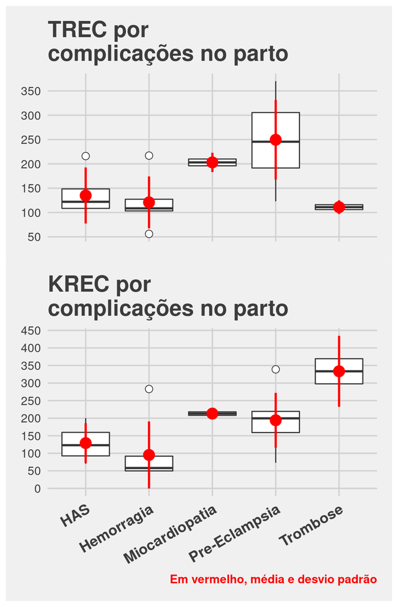

Medidas descritivas

|  | Min. | 1st Qu. | Median | Mean | 3rd Qu. | Max. | n |
| --- | --- | --- | --- | --- | --- | --- | --- |
| **TREC** |  |  |  |  |  |  |  |
| HAS | 80 | 108.50 | 122.0 | 135.00 | 148.50 | 216 | 4 |
| Hemorragia | 56 | 103.25 | 108.5 | 120.83 | 127.25 | 217 | 6 |
| Miocardiopatia | 189 | 196.00 | 203.0 | 203.00 | 210.00 | 217 | 2 |
| Pre-Eclampsia | 123 | 191.50 | 245.5 | 249.50 | 305.50 | 370 | 8 |
| Trombose | 101 | 106.00 | 111.0 | 111.00 | 116.00 | 121 | 2 |
| NA | 26 | 84.25 | 135.5 | 169.63 | 214.50 | 855 | 178 |
| **KREC** |  |  |  |  |  |  |  |
| HAS | 70 | 92.50 | 123.0 | 129.00 | 159.50 | 200 | 4 |
| Hemorragia | 22 | 49.75 | 58.0 | 95.17 | 91.75 | 283 | 6 |
| Miocardiopatia | 203 | 208.00 | 213.0 | 213.00 | 218.00 | 223 | 2 |
| Pre-Eclampsia | 73 | 159.00 | 199.5 | 194.00 | 219.25 | 339 | 8 |
| Trombose | 262 | 297.75 | 333.5 | 333.50 | 369.25 | 405 | 2 |
| NA | 19 | 45.00 | 73.5 | 112.62 | 132.75 | 791 | 178 |

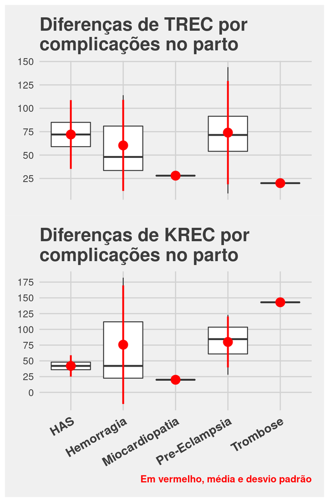

Medidas descritivas

|  | Min. | 1st Qu. | Median | Mean | 3rd Qu. | Max. | n |
| --- | --- | --- | --- | --- | --- | --- | --- |
| **TREC** |  |  |  |  |  |  |  |
| HAS | 46 | 59.0 | 72.0 | 72.00 | 85.0 | 98 | 2 |
| Hemorragia | 19 | 33.5 | 48.0 | 60.33 | 81.0 | 114 | 3 |
| Miocardiopatia | 28 | 28.0 | 28.0 | 28.00 | 28.0 | 28 | 1 |
| Pre-Eclampsia | 9 | 54.0 | 71.5 | 74.00 | 91.5 | 144 | 4 |
| Trombose | 20 | 20.0 | 20.0 | 20.00 | 20.0 | 20 | 1 |
| NA | 0 | 24.0 | 43.0 | 75.80 | 94.0 | 584 | 89 |
| **KREC** |  |  |  |  |  |  |  |
| HAS | 30 | 36.0 | 42.0 | 42.00 | 48.0 | 54 | 2 |
| Hemorragia | 3 | 22.5 | 42.0 | 75.67 | 112.0 | 182 | 3 |
| Miocardiopatia | 20 | 20.0 | 20.0 | 20.00 | 20.0 | 20 | 1 |
| Pre-Eclampsia | 28 | 61.0 | 84.5 | 80.00 | 103.5 | 123 | 4 |
| Trombose | 143 | 143.0 | 143.0 | 143.00 | 143.0 | 143 | 1 |
| NA | 0 | 14.0 | 29.0 | 44.60 | 53.0 | 278 | 89 |

# Peso

Medidas descritivas

| Min. | 1st Qu. | Median | Mean | 3rd Qu. | Max. | n |
| --- | --- | --- | --- | --- | --- | --- |
| 960 | 2091.5 | 2400 | 2352.613 | 2662 | 3780 | 194 |

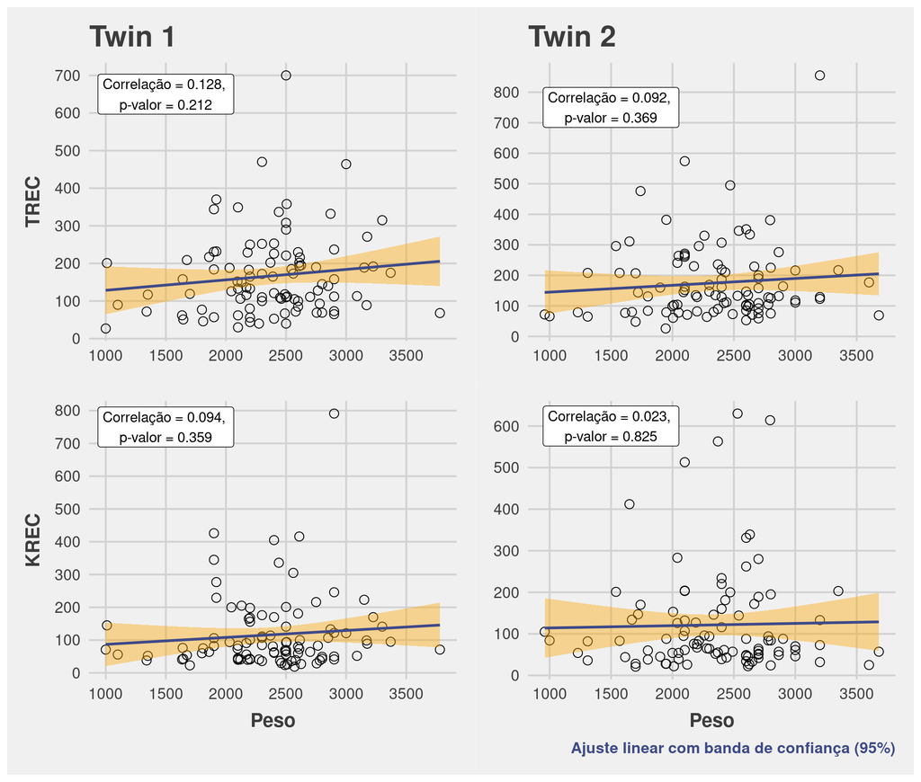

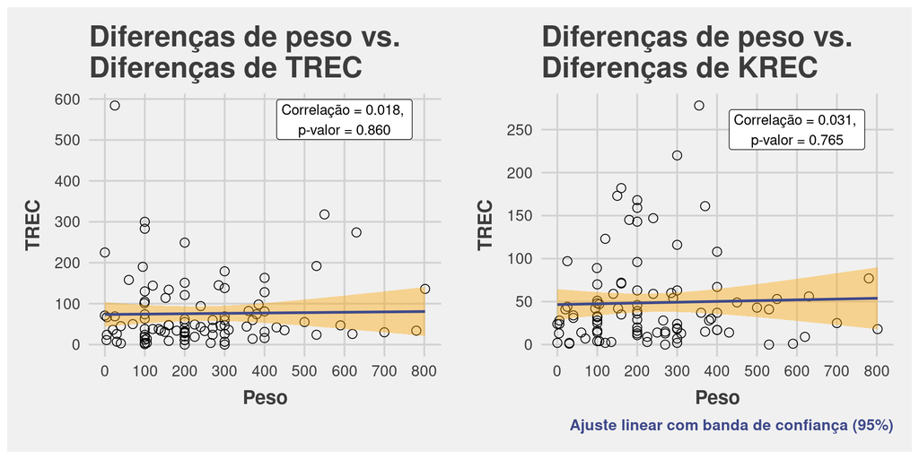

# Zigocidade

> Retirando o par `errado`.

| ID | id_gest | parto | complic_gest | complic_no_parto | Zigocidade | TREC | KREC |
| --- | --- | --- | --- | --- | --- | --- | --- |
| PG72a | 38 | Não informado | Não informado | Não informado | ERRADO | 160 | 254 |
| PG72b | 38 | Não informado | Não informado | Não informado | ERRADO | 174 | 246 |

Medidas descritivas (n representa o número de gêmeos, não de pares)

|  | Min. | 1st Qu. | Median | Mean | 3rd Qu. | Max. | n |
| --- | --- | --- | --- | --- | --- | --- | --- |
| **TREC** |  |  |  |  |  |  |  |
| diz | 26 | 92.75 | 144.5 | 169.605 | 216.25 | 855 | 152 |
| monoz | 30 | 81.00 | 111.5 | 173.239 | 229.50 | 574 | 46 |
| **KREC** |  |  |  |  |  |  |  |
| diz | 19 | 49.00 | 75.0 | 111.882 | 126.25 | 791 | 152 |
| monoz | 22 | 43.25 | 82.5 | 136.370 | 198.75 | 513 | 46 |
| **TRECdif** |  |  |  |  |  |  |  |
| diz | 0 | 26.00 | 46.0 | 79.132 | 107.25 | 584 | 152 |
| monoz | 0 | 22.00 | 40.0 | 60.304 | 60.00 | 283 | 46 |
| **KRECdif** |  |  |  |  |  |  |  |
| diz | 0 | 14.00 | 33.5 | 50.395 | 59.25 | 278 | 152 |
| monoz | 1 | 14.50 | 24.0 | 40.217 | 52.50 | 168 | 46 |

Testes-t de Welch

| Variável | estimate | estimate1 | estimate2 | p.value | conf.low | conf.high |
| --- | --- | --- | --- | --- | --- | --- |
| TREC | -3.6339 | 169.6053 | 173.2391 | 0.8642 | -45.8775 | 38.6098 |
| KREC | -24.4880 | 111.8816 | 136.3696 | 0.2342 | -65.1854 | 16.2094 |
| TRECdif | 18.8272 | 79.1316 | 60.3043 | 0.3034 | -17.5732 | 55.2277 |
| KRECdif | 10.1773 | 50.3947 | 40.2174 | 0.3682 | -12.3793 | 32.7340 |

> As médias não diferem, em nenhum dos cenários.

# Sexo

Medidas descritivas (n representa o número de gêmeos, não de pares)

|  | Min. | 1st Qu. | Median | Mean | 3rd Qu. | Max. | n |
| --- | --- | --- | --- | --- | --- | --- | --- |
| **TREC** |  |  |  |  |  |  |  |
| Feminino | 26 | 101.50 | 164.5 | 193.300 | 234.75 | 855 | 90 |
| Masculino | 40 | 80.00 | 125.5 | 151.691 | 194.50 | 495 | 110 |
| **KREC** |  |  |  |  |  |  |  |
| Feminino | 21 | 56.25 | 83.5 | 126.200 | 156.25 | 630 | 90 |
| Masculino | 19 | 43.00 | 67.5 | 112.918 | 143.00 | 791 | 110 |
| **TRECdif** |  |  |  |  |  |  |  |
| Both | 0 | 24.00 | 39.5 | 92.868 | 137.50 | 584 | 76 |
| Feminino | 7 | 41.25 | 58.5 | 89.500 | 103.25 | 318 | 52 |
| Masculino | 0 | 14.00 | 37.0 | 43.306 | 56.75 | 163 | 72 |
| **KRECdif** |  |  |  |  |  |  |  |
| Both | 1 | 16.25 | 39.0 | 56.763 | 62.25 | 220 | 76 |
| Feminino | 0 | 14.25 | 28.0 | 44.885 | 57.50 | 182 | 52 |
| Masculino | 1 | 12.00 | 28.5 | 39.972 | 51.75 | 278 | 72 |

Testes-t de Welch

| Variável | estimate | estimate1 | estimate2 | p.value | conf.low | conf.high |
| --- | --- | --- | --- | --- | --- | --- |
| TREC | 41.6091 | 193.3 | 151.6909 | 0.0155 | 8.0259 | 75.1923 |
| KREC | 13.2818 | 126.2 | 112.9182 | 0.4264 | -19.5824 | 46.1460 |

> Diferença significativa entre as médias dos sexos apenas entre as medidas de TREC.

Testes-t de Welch

| Variável | estimate | estimate1 | estimate2 | p.value | conf.low | conf.high |
| --- | --- | --- | --- | --- | --- | --- |
| **TRECdif** |  |  |  |  |  |  |
| Both vs. Feminino | 3.3684 | 92.8684 | 89.5000 | 0.8904 | -45.2906 | 52.0274 |
| Both vs. Masculino | 49.5629 | 92.8684 | 43.3056 | 0.0150 | 10.0720 | 89.0537 |
| Feminino vs. Masculino | 46.1944 | 89.5000 | 43.3056 | 0.0106 | 11.5255 | 80.8634 |
| **KRECdif** |  |  |  |  |  |  |
| Both vs. Feminino | 11.8785 | 56.7632 | 44.8846 | 0.3857 | -15.3306 | 39.0877 |
| Both vs. Masculino | 16.7909 | 56.7632 | 39.9722 | 0.1751 | -7.6499 | 41.2318 |
| Feminino vs. Masculino | 4.9124 | 44.8846 | 39.9722 | 0.7046 | -20.9409 | 30.7657 |

> Pares de gêmeos de sexos diferentes não diferem dos do sexo feminino, em termos de TREC médio. Contudo, eles diferem de maneira significativa dos do sexo masculino. Sexo feminino difere do sexo masculino. Tudo isso apenas para TREC.

# Infecção pós nascimento

> Retirando os não informados.

| ID | id_gest | parto | complic_gest | complic_no_parto | Zigocidade | infec_pos_nasc | TREC | KREC |
| --- | --- | --- | --- | --- | --- | --- | --- | --- |
| PG72a | 38 | Não informado | Não informado | Não informado | ERRADO | Não informado | 160 | 254 |
| PG72b | 38 | Não informado | Não informado | Não informado | ERRADO | Não informado | 174 | 246 |

Medidas descritivas (n representa o número de gêmeos, não de pares)

|  | Min. | 1st Qu. | Median | Mean | 3rd Qu. | Max. | n |
| --- | --- | --- | --- | --- | --- | --- | --- |
| **TREC** |  |  |  |  |  |  |  |
| Não | 26 | 95.5 | 135.0 | 170.086 | 209.50 | 855 | 139 |
| Sim | 27 | 80.0 | 140.0 | 171.305 | 230.00 | 495 | 59 |
| **KREC** |  |  |  |  |  |  |  |
| Não | 19 | 49.5 | 76.0 | 116.640 | 133.50 | 791 | 139 |
| Sim | 22 | 45.0 | 71.0 | 119.763 | 169.00 | 513 | 59 |
| **TRECdif** |  |  |  |  |  |  |  |
| Just one | 0 | 22.5 | 31.0 | 50.091 | 60.00 | 144 | 22 |
| Não | 0 | 25.5 | 49.5 | 80.922 | 98.75 | 584 | 128 |
| Sim | 4 | 27.0 | 38.0 | 69.625 | 96.75 | 274 | 48 |
| **KRECdif** |  |  |  |  |  |  |  |
| Just one | 3 | 15.5 | 46.0 | 54.727 | 67.50 | 173 | 22 |
| Não | 0 | 14.0 | 30.5 | 47.781 | 51.50 | 278 | 128 |
| Sim | 2 | 15.5 | 29.5 | 45.625 | 60.00 | 168 | 48 |

Testes-t de Welch

| Variável | estimate | estimate1 | estimate2 | p.value | conf.low | conf.high |
| --- | --- | --- | --- | --- | --- | --- |
| TREC | -1.2188 | 170.0863 | 171.3051 | 0.9444 | -35.7518 | 33.3143 |
| KREC | -3.1224 | 116.6403 | 119.7627 | 0.8585 | -37.7325 | 31.4877 |

Testes-t de Welch

| Variável | estimate | estimate1 | estimate2 | p.value | conf.low | conf.high |
| --- | --- | --- | --- | --- | --- | --- |
| **TRECdif** |  |  |  |  |  |  |
| Just one vs. Não | -30.8310 | 50.0909 | 80.9219 | 0.1159 | -69.7905 | 8.1286 |
| Just one vs. Sim | -19.5341 | 50.0909 | 69.6250 | 0.3591 | -62.4268 | 23.3586 |
| Não vs. Sim | 11.2969 | 80.9219 | 69.6250 | 0.5603 | -27.3494 | 49.9432 |
| **KRECdif** |  |  |  |  |  |  |
| Just one vs. Não | 6.9460 | 54.7273 | 47.7812 | 0.6941 | -30.1442 | 44.0363 |
| Just one vs. Sim | 9.1023 | 54.7273 | 45.6250 | 0.6280 | -29.7636 | 47.9682 |
| Não vs. Sim | 2.1562 | 47.7812 | 45.6250 | 0.8546 | -21.3570 | 25.6695 |

> Nenhum grupo difere de maneira significativa em termos da presença de infecção pós nascimento.

# Modelo

## TREC & KREC

> Modelamos as medidas de TREC e KREC conjuntamente em duas frentes: na média e na variância. Como temos mais de uma variável e vamos também modelar a correlação entre elas, chamamos de covariância.

> Para estudar a herdabilidade e o relacionamento genético e ambiental das medidas, usamos um modelo chamado de ACE. Basicamente, decompomos a matriz de variância-covariância (a partir daqui chamaremos simplesmente de matriz de covariância) em três matrizes:
> - A: efeito/componente genético/herdabilidade;
> - C: efeito/componente mútuo do ambiente (common environment);
> - E: efeito/componente único do ambiente (unique environment).

> Além de considerarmos essa decomposição da covariância podemos também colocar covariáveis nela.

> Tanto na média quanto na covariância usamos/testamos o efeito de seis covariáveis:
> - Peso;
> - Idade gestacional;
> - Tipo de parto;
> - Sexo;
> - Zigocidade;
> - Gêmeo (1 ou 2, para ver se realmente existe uma aleatoriedade na disposição sdos dados).

> A zigocidade é um termo chave dessa modelagem, dado que precisamos informar quantos pares de gêmeos são monozigotos e dizigotos. Portanto, o par que não tem essa informação foi descartado. Ficamos/usamos 198 gêmeos.

> Começamos com um modelo bivariado ACE, modelando TREC e KREC conjuntamento. Contudo, observamos $p$-valores muito altos para o componente C. Tal fato indica que tal componente não é necessário. Portanto, ajustamos um modelo AE e vemos se é melhor ficar com ele. Abaixo temos algumas medidas de qualidade do ajuste dos dois modelos.

```
  Model  plogLik Df    pAIC    pKLIC     pBIC
1   ACE -2353.64 23 4753.28 5405.218 4844.853
2    AE -2369.63 20 4779.26 5290.002 4858.888
```

> A primeira medida, plogLik, é do tipo maior-melhor, as demais são do tipo menor-melhor. De modo geral, o modelo ACE apresenta melhores medidas. Contudo ele tem três parâmetros a mais. A diferença das medidas entre os modelos não é grande o suficiente para justificar permanecermos com um modelo maior sendo que o componente C não é estatisticamente significativo. Assim, ficamos com o modelo bivariado AE.

> Agora, a seleção de variáveis. Começamos pela média. Das seis variáveis ficamos com apenas duas, ou seja, das seis apenas duas se mostram significativas. As medidas do modelo inicial e do final são apresentadas abaixo.

```
       Model  plogLik Df    pAIC    pKLIC     pBIC
1 AE initial -2372.17 11 4766.34 5441.763 4810.136
2   AE final -2372.17 11 4766.34 5441.763 4810.136
```

|  | Estimates | std.error | z value | Pr(>\|z\|) |
| --- | --- | --- | --- | --- |
| **TREC** |  |  |  |  |
| (Intercept) | -97.1912 | 127.8171 | -0.7604 | 0.4470 |
| id_gest | 8.0203 | 3.5627 | 2.2512 | 0.0244 |
| sexoMasculino | -34.7133 | 15.0805 | -2.3019 | 0.0213 |
| **KREC** |  |  |  |  |
| (Intercept) | -160.7853 | 126.7882 | -1.2681 | 0.2047 |
| id_gest | 7.7597 | 3.5385 | 2.1929 | 0.0283 |

> Para TREC as variáveis significativas são a idade gestacional e o sexo, i.e. a idade gestacional e o sexo do gêmeo tem uma associação significativa com os valor de TREC. Para o KREC, apenas a idade gestacional é significativa, o sexo é irrelevante (sem diferença significativa de um sexo para outro).

> Em todo modelo de regressão/estatístico temos um intercepto, quando falamos da interpretação dos coeficientes estimados. O intercepto é o nível de referência. Para o TREC, o intercepto corresponde a um gêmeo de idade gestacional média e do sexo feminino. Conforme aumentamos a idade gestacional aumentamos seu TREC no valor de seu coeficiente estimado (8.0203). Se o gêmeo é do sexo masculino, estimamos que seu TREC diminua 34.7133, em relação ao intercepto. Mesma ideia para o KREC e a idade gestacional.

> Agora, a covariância. Decompomos a variância do TREC (13698.1066), a variância do KREC (13787.0686) e a covariância entre os dois (4392.4173) da seguinte maneira.

|  | Estimates | std.error | Percentage | z value | Pr(>\|z\|) |
| --- | --- | --- | --- | --- | --- |
| Environment component (E) |  |  |  |  |  |
| TREC | 3712.4482 | 2751.5400 | 27.1019 | 1.3492 | 0.1773 |
| KREC | 1391.8790 | 4100.7340 | 10.0955 | 0.3394 | 0.7343 |
| TREC & KREC | 862.7034 | 490.8413 | 19.6407 | 1.7576 | 0.0788 |
| Genetic component (A) |  |  |  |  |  |
| TREC | 8703.5756 | 3370.8550 | 63.5385 | 2.5820 | 0.0098 |
| KREC | 9990.1531 | 5750.4968 | 72.4603 | 1.7373 | 0.0823 |
| TREC & KREC | 2633.3467 | 1090.5257 | 59.9521 | 2.4147 | 0.0157 |

> Temos as estimativas divididas pelos componentes ambiental e genético. Em outras palavras, quanto da variabilidade dos dados é explicada pelos tais componentes. Como podemos ver pela coluna percentage, a soma das estimativas (do TREC, por exemplo) não dá 1. Isso quer dizer que nem toda a variabilidade observada é explicada pelo componente ambiental ou genético.

> Vemos que o componente genético é muito mais significativo, principalmente no TREC. Continunando no TREC, a fim de didática, 27% (não significativo, $p$-valor de 0.177) da variabilidade observada é explicada pelo componente ambiental e 63% (significativo, $p$-valor de 0.0098) pelo componente genético.

> Abaixo temos as medidas de ambientalidade e herdabilidade. Vemos que apenas a herdabilidade é significativa, para ambos TREC e KREC.

|  | Estimates | std.error | z value | Pr(>\|z\|) |
| --- | --- | --- | --- | --- |
| **Environmentability** |  |  |  |  |
| TREC | 0.2990 | 0.2096 | 1.4267 | 0.1537 |
| KREC | 0.1223 | 0.3634 | 0.3365 | 0.7365 |
| **Heritability** |  |  |  |  |
| TREC | 0.7010 | 0.2096 | 3.3449 | 0.0008 |
| KREC | 0.8777 | 0.3634 | 2.4155 | 0.0157 |

|  | Estimates | std.error | z value | Pr(>\|z\|) |
| --- | --- | --- | --- | --- |
| Bivariate environmentability | 0.2468 | 0.1580 | 1.5619 | 0.1183 |
| Environment correlation | 0.3795 | 0.5943 | 0.6386 | 0.5231 |
| Bivariate heritability | 0.7532 | 0.1580 | 4.7676 | 0.0000 |
| Genetic correlation | 0.2824 | 0.1397 | 2.0209 | 0.0433 |

> A única correlação significativa é a genética, a ambiental não é. Seguindo a mesma ideia, a herdabilidade bivariada/conjunta é significativa. A ambiental não é.

> Tentamos verificar o efeito das covariáveis também na covariância, i.e. “quebrar” as medidas apresentadas acima pelas covariáveis, mas não conseguimos. Estamos lidando com um modelo bem complexo e nosso tamanho amostral não é grande. Portanto, não conseguimos convergência nos modelos bivariados com covariáveis na covariância. Solução? Ajustar modelos univariados. Os componentes de média se mantém exatamente os mesmos.

## TREC

> Partimos do modelo AE com idade gestacional e sexo como covariáveis na média e fizemos a seleção de covariáveis na covariância. Das seis covariáveis nenhuma é significativa no componente E, ambiental. No componente A, genético, a variável parto é significativa.

|  | Estimates | Std.error | Percentage |
| --- | --- | --- | --- |
| Environment component (E) | 3534.162 | 2773.739 | 25.8004 |
| **Genetic component (A)** |  |  |  |
| partoCesariana | 9851.598 | 3647.523 | 71.9194 |
| partoNormal | -10976.948 | 3140.646 | -80.1348 |

> 26% da variabilidade observada é explicada/atribuída pelo componente ambiental. O tipo de parto é significativo no componente genético. Com um gêmeo que teve parto do tipo cesaria, o componente genético explica 72% da variabilidade. Ou seja, os componentes ambiental e genético explicam cerca de 98% de toda a variabilidade da variável TREC. Agora, num gêmeo que teve parto normal, (o poder de) explicação cai 80%. Ou seja, num gêmeo com parto normal o componente genético não explica nada da variabilidade. Isso é justificado pela (baixa) representatividade nos dados, 7% apenas dos gêmeos tiveram parto normal (ou seja, a incerteza inerente é muito alta).

## KREC

> Partimos do modelo AE com idade gestacional como covariável na média e fizemos a seleção de covariáveis na covariância. Das seis covariáveis, tipo de parto e zigocidade são significativas no componente E, ambiental. No componente A, genético, a variável parto é significativa.

|  | Estimates | Std.error | Percentage |
| --- | --- | --- | --- |
| **Environment component (E)** |  |  |  |
| partoCesariana.zigocidadeDZ | -8562.138 | 3940.7251 | -62.1027 |
| partoNormal | 9185.825 | 4003.8748 | 66.6264 |
| zigocidadeMZ | 9829.275 | 609.2463 | 71.2934 |
| **Genetic component (A)** |  |  |  |
| partoCesariana | 22781.346 | 3823.2523 | 165.2371 |
| partoNormal | -22636.617 | 3909.9002 | -164.1873 |

> Num gêmeo com parto tipo cesaria e dizigoto, nada da variabilidade do KREC é explicada pelo componente ambiental (-62%). Contudo, se mudamos para um gêmeo de parto normal a explicação cresce 66%, ou seja, 4% (-62 + 66) da variabilidade é explicada pelo componente ambiental. Num gêmeo monozigoto o percentual explicado é 9% (-62 + 71).

> Quando olhamos para o componente genético a diferença entre tipos de parto é abismal. Num gëmeo dizigoto de parto tipo cesaria temos 103% (-62 + 165) da variabilidade unicamente explicada pelo componente genético. Tal efeito é tão grande mas ao mesmo incerto, que o percentual estoura. No caso de parto normal temos exatamente o contrário. O desbalancemanto das frequências de tipo de parto na base de dados acaba gerando esses resultados “estranhos”.

# Referências

> A análise estatística foi performada com a linguagem e ambiente para computação estatística `R` (R Core Team, 2021). Para descrever a relação das medidas de TREC, KREC, idade gestacional e peso ao nascimento, gráficos de dispersão em conjunto com análises de regressão linear foram aplicadas. Já para as variáveis qualitativas, gráficos de caixa (*boxplots*) e medidas descritivas e exploratórias foram calculadas. Diferenças de média entre grupos tiveram sua significância testada através de testes-*t* de hipótese. Modelos multivariados de regressão feitos para lidar com as interrelações genéticas e ambientais de dados de gêmeos (Bonat and Hjelmborg, 2022) foram aplicados para entender a dinâmica das medidas de TREc e KREC. Os principais pacotes `R` utlizados na análise foram: `{dplyr}` (Wickham et al., 2021), `{stringr}` (Wickham, 2019), `{ggplot2}` (Wickham, 2016), `{tidyr}` (Wickham, 2021), `{broom}` (Robinson et al., 2021), e `{mglm4twin}` (Bonat, 2018).

> R Core Team (2021). R: A language and environment for statistical computing. R Foundation for Statistical Computing, Vienna, Austria. URL https://www.R-project.org/

> Wickham, H., François, R., Henry, L., Müller, K. (2021). dplyr: A Grammar of Data Manipulation. R package version 1.0.7. https://CRAN.R-project.org/package=dplyr

> Wickham, H. (2019). stringr: Simple, Consistent Wrappers for Common String Operations. R package version 1.4.0. https://CRAN.R-project.org/package=stringr

> Wickham, H. (2016). ggplot2: Elegant Graphics for Data Analysis. Springer-Verlag New York.

> Wickham, H. (2021). tidyr: Tidy Messy Data. R package version 1.1.3. https://CRAN.R-project.org/package=tidyr

> Robinson, D., Hayes, A., Couch, S. (2021). broom: Convert Statistical Objects into Tidy Tibbles. R package version 0.7.8. https://CRAN.R-project.org/package=broom

> W. H (2018). mglm4twin: Multivariate Generalized linear models for twin data. R package version 0.1.0. https://github.com/wbonat/mglm4twin

> Bonat, W. H., Hjelmborg, J. V. B. Multivariate Generalized Linear Models for Twin and Family Data. Behav Genet (2022). https://doi.org/10.1007/s10519-021-10095-3